# DÍA 1

Curso teórico-práctico de introducción a la secuenciación con tecnología Oxford Nanopore Technologies para la caracterización de microorganismos

2 de diciembre de 2024

### **1. Introducción**

Los datos de secuenciación de microorganismos generados en cualquiera de las plataformas disponibles deben ser analizados utilizando herramientas que permitan realizar el control de calidad, el ensamblado de los contigs genómicos, la determinación de la completitud del genoma, la anotación completa o de grupos de genes específicos y la comparación de éste genoma con otros.

En los próximos días estaremos realizando una introducción al análisis de los datos de secuenciación ONT utilizando la línea de comando y acercarnos a las ventajas del uso del manejo del lenguaje de programación R para la generación de visualizaciones.

En la **Figura** 1 pueden ver los módulos del curso prático y que estarán utilizando para el análisis de los genomas generados en el curso. La introducción al análisis consta de:  
1. Control de calidad de los datos de secuenciación (Illumina y ONT).  
2. Ensamblado de genomas a partir de lecturas de secuenciación de Illumina, ONT y ambos.  
3. Anotación de genes de resistencia a antimicrobianos (RAM) y virulencia.  
4. Determinación del *cg*MLST.  
5. Clasificación de los contigs plasmídicos.  
6. Determinación de las relaciones filogenéticas de los genomas obtenidos en el curso con otros extraídos de la base de datos.

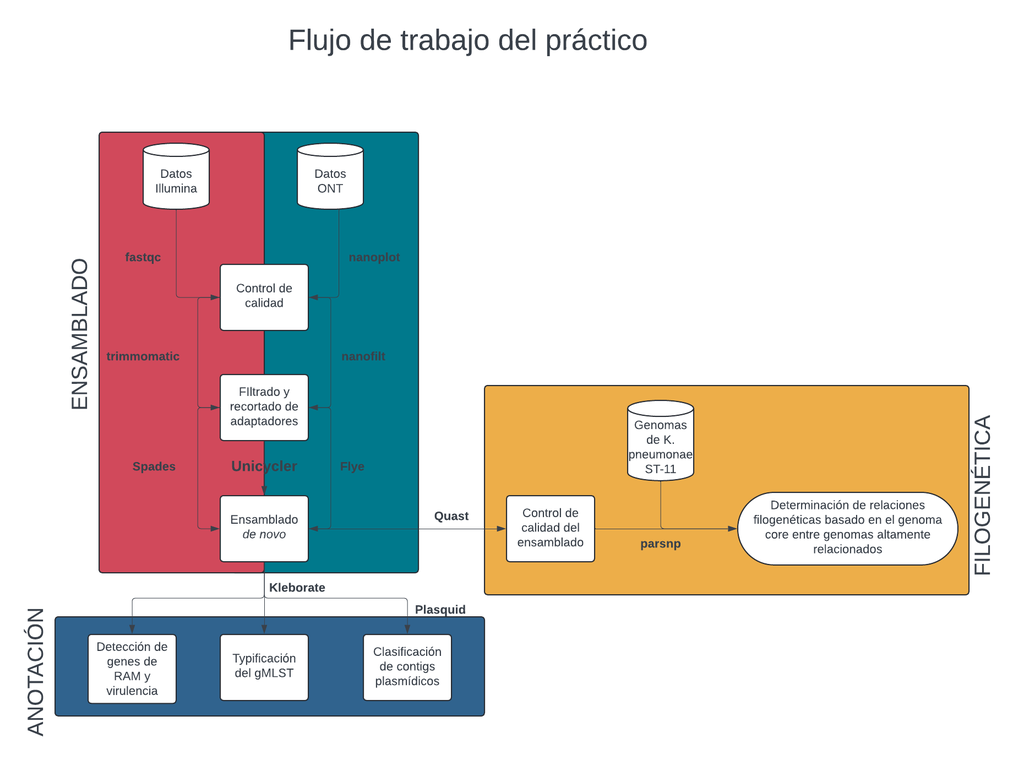

**Figura 1**: Análisis de datos de secuenciación de los genomas de *Klebsiella pneumoniae*.

### **2. Objetivos del día**

1. Familiarizarnos con el flujo de trabajo.
2. Ubicar los datos de secuenciación y entender la estructura de archivos.
3. Repasar comandos básicos para navegar en la línea de comando UNIX.
4. Entender el sistema de instalación que estamos utilizando.

### **3. Localización de los datos y repaso de comandos básico de la línea de comando**

Los datos que utilizaremos para el práctico están localizados en el directorio *curso_ont_2024* dentro del directorio *Documentos* localizado en el *home* del sistema.  
Para movernos al directorio correspondiente, utilizaremos el siguiente comando:

```
cd $DIR_CURSO/curso_ont_2024
```

**La variable $DIR_CURSO apunta hacia un directorio dentro del sistema.**

Para visualizar el contenido en del directorio utilizando el siguiente comando utilizando el **PATH absoluto**:

```
ls $DIR_CURSO/curso_ont_2024
```

Si se encuentra dentro del directorio *curso_ont_2024*, puede utilizar el **PATH relativo**:

```
ls .
```

Alternativamente, puede utilizar el comando

```
ll .
```

En este directorio se encuentran dos subdirectorios que contienen los datos de secuenciación del genoma completo (Whole Genome Sequencing, WGS, por sus siglas en inglés) de la muestra F19 de *Klebsiella penumoniae*: *illumina_data* y *ont_data*, respectivamente.  
Para esta muestra, los datos de secuenciación corresponden a los obtenidos con secuenciación Illumina HiSeq 4000 150 bp PE y Oxford Nanopore con la estrategia de ligación (SKQ-LSK109).

En la carpeta *scripts* encontraremos los comandos que estaremos utilizando para  
1. El control de calidad (QC) de los datos de secuenciación.  
2. El ensamblado del genoma de la *K. pneumoniae* F19 a partir de las lecturas cortas y largas.  
3. El ensamblado híbrido del genoma de *K. pneumoniae* F19 a partir de las lecturas cortas y largas.  
4. La anotación de genes de resistencia, virulencia y cgMLST.  
5. Clasificación de contigs plasmídicos.  
6. Localización filogenética del genoma de *K. pneumoniae* F19, respecto a otros genomas de *K. pneumoniae* obtenidos de la base de datos [BV-BRC: Bacterial and Viral Bioinformatics Resource Center](https://www.bv-brc.org/).  
7. R scripts para la visualización primaria de los resultados.

#### 3.1 Visualización del contenido de los archivos de texto

```
head -n 20 $DIR_CURSO/curso_ont_2024/scripts/1.fastqc.sh
```

Alternativamente se pueden utilizar los comandos:

```
more $DIR_CURSO/curso_ont_2024/scripts/1.fastqc.sh
less $DIR_CURSO/curso_ont_2024/scripts/1.fastqc.sh
```

#### 3.2 Realizar una copia de un archivo y eliminar archivo.

```
cp $DIR_CURSO/curso_ont_2024/scripts/1.fastqc.sh $DIR_CURSO/curso_ont_2024/scripts/copia_1.fastqc.sh
rm $DIR_CURSO/curso_ont_2024/scripts/copia_1.fastqc.sh
```

#### 3.3 Edición de contenidos de archivos de texto

Para editar los archivos de texto utilizaremos el comando **nano** y seguiremos las instrucciones que se muestran en el pie de la pantalla para guardar o descartar cambios

```
cp $DIR_CURSO/curso_ont_2024/scripts/1.fastqc.sh $DIR_CURSO/curso_ont_2024/scripts/copia_1.fastqc.sh
nano $DIR_CURSO/curso_ont_2024/scripts/copia_1.fastqc.sh
rm $DIR_CURSO/curso_ont_2024/scripts/copia_1.fastqc.sh
```

Alternativamente, podemos abrir el archivo con un editor de texto instalado en el sistema como *gedit*.

#### 3.4 Utilización de contenedores

La instalación del software que utilizaremos en el curso se realizó utilizando **CONDA**, un sistema de gestión de paquetes (o herramientas) y entornos [ANACONDA](https://anaconda.org/). El nombre del ambiente de conda que utilizaremos y que contiene todas las herramientas necesarias se llama *genomics*. Si desea instalar en su sistema este entorno podrá hacerlo utilizando el archivo .yml en el GitHub del curso. Deberá tener CONDA instalado en su sistema previamente.

**ATENCIÓN: En las máquinas del curso este entorno ya fue instalado y no deberá hacer nada al respecto**.

```
conda env create -f genomics.yml
```

Para ver la lista de herramientas presentes ejecute los siguientes comandos

```
conda activate genomics
conda list
```

Podrá instalar paquetes adicionales al entorno, simpre y cuando no haya conflicto de versiones en las dependencias.  
Adicionalmente, deberá tener instalado **R** y **RStudio** (Posit) en su sistema para poder ejecutar los scripts de R.

### **4. Ejecución de scripts**

Los scripts con los comandos que utilizaremos se encuentran en el subdirectorio *scripts* del directorio de trabajo *curso_ont_2024*. Los archivos con el sufijo “.sh” corresponden a scripts interpretados por los sistemas Unix (Linux, macOS). El intérprete se conoce como Bash y estos scripts se caracterizan por tener el encabezado #!/bin/bash. Los scripts con el sufijo “.R” corresponden a los scripts que son interpretados por Rscript para la ejecución de comandos de R.

Para que el intéprete Bash pueda ejecutar los scripts, los mismos deben tener el permiso de ejecución:

```
chmod +x $DIR_CURSO/curso_ont_2024/scripts/1.fastqc.sh
```

La ejecución de los comandos en el script viene dado por el siguiente comando:

```
./scripts/1.fastqc.sh
```

“./” buscará ejecutar el script *1.fastqc.sh* dento del directorio *scripts*

A diferencia de los scripts .sh, los scripts .R no requieren un encabezado específico, ya que son ejecutados directamente por el intérprete Rscript.

```
Rscript $DIR_CURSO/curso_ont_2024/scripts/1_rscript_nanoplot.R
```

Alternativamente, se pueden abrir en Rstudio y ejecutar los comandos presentes en este script. Esto tiene la ventaja que los scripts pueden ser adaptados y personalizados.

### **5. Archivos FASTQ**

### 5.1 Formato de las lecturas de secuenciación de Illumina

```
head -n 5 $DIR_CURSO/curso_ont_2024/illumina_data/*.fastq
```

### 5.2 Formato de las lecturas de secuenciación de ONT

```
head -n 5 $DIR_CURSO/curso_ont_2024/ont_data/*.fastq
```

### **6. Preguntas para ir contestando a lo largo del curso**

1. ¿En qué formatos se encuentran los datos de secuenciación?
2. ¿Cómo se define la calidad de las secuencias para los datos de Illumina y de ONT?
3. ¿Qué es la tasa de error en la secuenciación y cómo se relaciona con la precisión?
4. ¿A qué nos referimos cuando anotamos genes?
5. ¿Cómo describiría en pocas palabras, en qué consiste el ensamblado de genomas?
6. ¿Qué es el genoma *core* de un microorganismo?
7. ¿Qué información nos puede brindar una filogenia basada en SNPs (del ingés *single nucleotide polymorphisms*) del genoma *core*?
8. ¿Qué otros métodos basados en secuenciación permiten caracterizar microorganismos bacterianos?

#### Glosario:

**Genoma**: Conjunto completo de material genético en un organismo.  
**Ensamblado genómico**: proceso computacional que reconstruye la secuencia completa de un genoma a partir de fragmentos de ADN obtenidos mediante tecnologías de secuenciación.  
**Lecturas (Reads)**: Fragmentos cortos de ADN generados por tecnologías de secuenciación.  
**Contig**: Secuencia continua de ADN ensamblada a partir de lecturas que se solapan.  
**Scaffold**: Estructura que organiza contigs en orden y orientación.  
**Gaps**: Regiones no secuenciadas entre contigs dentro de un scaffold.  
**N50**: Métrica que mide el tamaño de los contigs o scaffolds. Es la longitud mínima del contig más largo que suma al menos el 50% del ensamblado total.  
**Ensamblado *de novo***: Proceso de reconstrucción de un genoma sin una referencia previa.  
**Ensamblado guiado por referencia**: Método que usa un genoma conocido como template para ensamblar las lecturas.  
**K-mer**: Secuencia de ADN de longitud fija K.  
**Secuenciación**: Proceso de determinar la orden de las bases (A, C, G, T) en una molécula de ADN.  
**Repetidos genómicos**: Secuencias de ADN idénticas o muy similares que aparecen en múltiples lugares del genoma, dificultando el ensamblado.  
**Error de secuenciación**: Errores introducidos durante el proceso de secuenciación que pueden afectar la precisión del ensamblado.  
**Cobertura (Coverage)**: Número promedio de veces que cada base del genoma es representada en las lecturas.  
**Polimorfismo**: Variación en la secuencia de ADN entre individuos o dentro de un organismo no clonal.  
**Paired-end sequencing (PE)**: Método de secuenciación que genera lecturas desde ambos extremos de un fragmento de ADN.